# Final Project Notebook

DS 5001 Text as Data | Spring 2025

# Metadata

- Full Name: Andrew Cornfeld
- Userid: cpm6gh
- GitHub Repo URL: https://github.com/AndrewCornfeld/DS5001FinalProject/tree/master
- UVA Box URL: https://virginia.app.box.com/folder/313602731077

# Overview

The goal of the final project is for you to create a **digital analytical edition** of a corpus using the tools, practices, and perspectives you’ve learning in this course. You will select a corpus that has already been digitized and transcribed, parse that into an F-compliant set of tables, and then generate and visualize the results of a series of fitted models. You will also draw some tentative conclusions regarding the linguistic, cultural, psychological, or historical features represented by your corpus. The point of the exercise is to have you work with a corpus through the entire pipeline from ingestion to interpretation.

Specifically, you will acquire a collection of long-form texts and perform the following operations:

- **Convert** the collection from their source formats (F0) into a set of tables that conform to the Standard Text Analytic Data Model (F2).
- **Annotate** these tables with statistical and linguistic features using NLP libraries such as NLTK (F3).
- **Produce** a vector representation of the corpus to generate TFIDF values to add to the TOKEN (aka CORPUS) and VOCAB tables (F4).
- **Model** the annotated and vectorized model with tables and features derived from the application of unsupervised methods, including PCA, LDA, and word2vec (F5).
- **Explore** your results using statistical and visual methods.
- **Present** conclusions about patterns observed in the corpus by means of these operations.

When you are finished, you will make the results of your work available in GitHub (for code) and UVA Box (for data). You will submit to Gradescope (via Canvas) a PDF version of a Jupyter notebook that contains the information listed below.

# Some Details

- Please fill out your answers in each task below by editing the markdown cell.
- Replace text that asks you to insert something with the thing, i.e. replace `(INSERT IMAGE HERE)` with an image element, e.g. `![](image.png)`.
- For URLs, just paste the raw URL directly into the text area. Don't worry about providing link labels using `[label](link)`.
- Please do not alter the structure of the document or cell, i.e. the bulleted lists.
- You may add explanatory paragraphs below the bulleted lists.
- Please name your tables as they are named in each task below.
- Tasks are indicated by headers with point values in parentheses.

# Raw Data

## Source Description (1)

Provide a brief description of your source material, including its provenance and content. Tell us where you found it and what kind of content it contains.

My source material is the entire script of the TV show "The Office". I found this on a reddit post. It contains every line from every character in every episode of every season, as well as the character that said it and whether or not it was deleted.

https://docs.google.com/spreadsheets/d/18wS5AAwOh8QO95RwHLS95POmSNKA2jjzdt0phrxeAE0/edit?gid=747974534#gid=747974534

## Source Features (1)

Add values for the following items. (Do this for all following bulleted lists.)

- Source URL: https://www.reddit.com/r/datasets/comments/b30288/every_line_from_every_episode_of_the_office/
- UVA Box URL: https://virginia.box.com/s/99tgptdeotyu02cheyzbjtyqnl7izpvj
- Number of raw documents: 1
- Total size of raw documents (e.g. in MB): 5189 KB
- File format(s), e.g. XML, plaintext, etc.: CSV

## Source Document Structure (1)

Provide a brief description of the internal structure of each document. That, describe the typical elements found in document and their relation to each other. For example, a corpus of letters might be described as having a date, an addressee, a salutation, a set of content paragraphs, and closing. If they are various structures, state that.

The document's columns include a unique identifier (id), the season number, episode number, scene number. It also contains the line text, which sometimes can contain other details about how the line was spoken (ex: [on the phone], [singing], [Dwight begins smashing pencils with his phone]). It also notes the speaker and whether or not the line was deleted, which is a boolean value.

# Parsed and Annotated Data

Parse the raw data into the three core tables of your addition: the `LIB`, `CORPUS`, and `VOCAB` tables.

These tables will be stored as CSV files with header rows.

You may consider using `|` as a delimitter.

Provide the following information for each.

## LIB (2)

The source documents the corpus comprises. These may be books, plays, newspaper articles, abstracts, blog posts, etc.

Note that these are *not* documents in the sense used to describe a bag-of-words representation of a text, e.g. chapter.

- UVA Box URL: https://virginia.box.com/s/uhm4qo4w8r6hczoqsn5yni59h9q7p9fd
- GitHub URL for notebook used to create: https://github.com/AndrewCornfeld/DS5001FinalProject/blob/master/LibCorpusVocabImport.ipynb
- Delimitter: ","
- Number of observations: 1
- List of features, including at least three that may be used for model summarization (e.g. date, author, etc.): number of seasons, author, episode
- Average length of each document in characters: 2705403

## CORPUS (2)

The sequence of word tokens in the corpus, indexed by their location in the corpus and document structures.

- UVA Box URL: https://virginia.box.com/s/qt2fmg4s4tbuhqh2oowjzoxy5k5t44uv
- GitHub URL for notebook used to create: https://github.com/AndrewCornfeld/DS5001FinalProject/blob/master/LibCorpusVocabImport.ipynb
- Delimitter: ","
- Number of observations Between (should be >= 500,000 and <= 2,000,000 observations.): 826446
- OHCO Structure (as delimitted column names): ['season', 'episode', 'scene', 'line', 'sentence', 'token']
- Columns (as delimitted column names, including `token_str`, `term_str`, `pos`, and `pos_group`): ['pos_tuple', 'pos', 'token_str', 'term_str', 'pos_group']

## VOCAB (2)

The unique word types (terms) in the corpus.

- UVA Box URL: https://virginia.box.com/s/uhm4qo4w8r6hczoqsn5yni59h9q7p9fd
- GitHub URL for notebook used to create: https://github.com/AndrewCornfeld/DS5001FinalProject/blob/master/LibCorpusVocabImport.ipynb
- Delimitter: ","
- Number of observations: 22338
- Columns (as delimitted names, including `n`, `p`', `i`, `dfidf`, `porter_stem`, `max_pos` and `max_pos_group`, `stop`): ['term_rank', 'n', 'p', 'i', 'n_chars', 'max_pos_group', 'max_pos', 'n_pos_group', 'n_pos', 'stop', 'porter_stem', 'df', 'idf', 'dfidf']
- Note: Your VOCAB may contain ngrams. If so, add a feature for `ngram_length`.
- List the top 20 significant words in the corpus by DFIDF.

i, you, the, to, a, s, it, that, and, is, do, nt, of, what, in, this, we, on, have, me

# Derived Tables

## BOW (3)

A bag-of-words representation of the CORPUS.

- UVA Box URL: https://virginia.box.com/s/u56i541rc98x6ns1cinv4blryz7o8h2l
- GitHub URL for notebook used to create: https://github.com/AndrewCornfeld/DS5001FinalProject/blob/master/LibCorpusVocabImport.ipynb
- Delimitter: ','
- Bag (expressed in terms of OHCO levels): OHCO[:4]
- Number of observations: 652040
- Columns (as delimitted names, including `n`, `tfidf`): ['n', 'tfidf']

## DTM (3)

A represenation of the BOW as a sparse count matrix.

- UVA Box URL: https://virginia.box.com/s/tma3uquymd40bcnt40ocj1dd6ric8pl4
- UVA Box URL of BOW used to generate (if applicable): https://virginia.box.com/s/u56i541rc98x6ns1cinv4blryz7o8h2l
- GitHub URL for notebook used to create: https://github.com/AndrewCornfeld/DS5001FinalProject/blob/master/LibCorpusVocabImport.ipynb
- Delimitter: ','
- Bag (expressed in terms of OHCO levels): OHCO[:4]

## TFIDF (3)

A Document-Term matrix with TFIDF values.

- UVA Box URL: https://virginia.box.com/s/9rzt63nrix6ijpv8ijpy9lhdf9xg5pnc
- UVA Box URL of DTM or BOW used to create: https://virginia.box.com/s/u56i541rc98x6ns1cinv4blryz7o8h2l
- GitHub URL for notebook used to create: https://github.com/AndrewCornfeld/DS5001FinalProject/blob/master/LibCorpusVocabImport.ipynb
- Delimitter: ','
- Description of TFIDIF formula ($\LaTeX$ OK): TF = (DCTM.T / DCTM.T.sum()).T

IDF = log2(N / DF) TFIDF = TF * IDF

## Reduced and Normalized TFIDF_L2 (3)

A Document-Term matrix with L2 normalized TFIDF values.

- UVA Box URL: https://virginia.box.com/s/wfhj46lddiye8jqgg3qwj35usdnjm7br
- UVA Box URL of source TFIDF table: https://virginia.box.com/s/9rzt63nrix6ijpv8ijpy9lhdf9xg5pnc
- GitHub URL for notebook used to create: https://github.com/AndrewCornfeld/DS5001FinalProject/blob/master/LibCorpusVocabImport.ipynb
- Delimitter: ','
- Number of features (i.e. significant words): 22338
- Principle of significant word selection: Highest frequency.

# Models

## PCA Components (4)

- UVA Box URL: https://virginia.box.com/s/qliugkwx1qz7zdgompy50kmu59vcegz2
- UVA Box URL of the source TFIDF_L2 table: https://virginia.box.com/s/wfhj46lddiye8jqgg3qwj35usdnjm7br
- GitHub URL for notebook used to create: https://github.com/AndrewCornfeld/DS5001FinalProject/blob/master/LibCorpusVocabImport.ipynb
- Delimitter: ','
- Number of components: 10
- Library used to generate: PCA from sklearn.decomposition
- Top 5 positive terms for first component: yes oh hell yeap totally
- Top 5 negative terms for second component: okay no hey what you

## PCA DCM (4)

The document-component matrix generated.

- UVA Box URL: 'https://virginia.box.com/s/defqs26x5dgo82mlz59lj3adozhglkrd'
- GitHub URL for notebook used to create: https://github.com/AndrewCornfeld/DS5001FinalProject/blob/master/LibCorpusVocabImport.ipynb
- Delimitter: ','

## PCA Loadings (4)

The component-term matrix generated.

- UVA Box URL: https://virginia.box.com/s/ra8nwcpjmlwd76n9rn5qbch6ahfkt9m0
- GitHub URL for notebook used to create: https://github.com/AndrewCornfeld/DS5001FinalProject/blob/master/LibCorpusVocabImport.ipynb
- Delimitter: ','

## PCA Visualization 1 (4)

Include a scatterplot of documents in the space created by the first two components.

Color the points based on a metadata feature associated with the documents.

Also include a scatterplot of the loadings for the same two components. (This does not need a feature mapped onto color.)

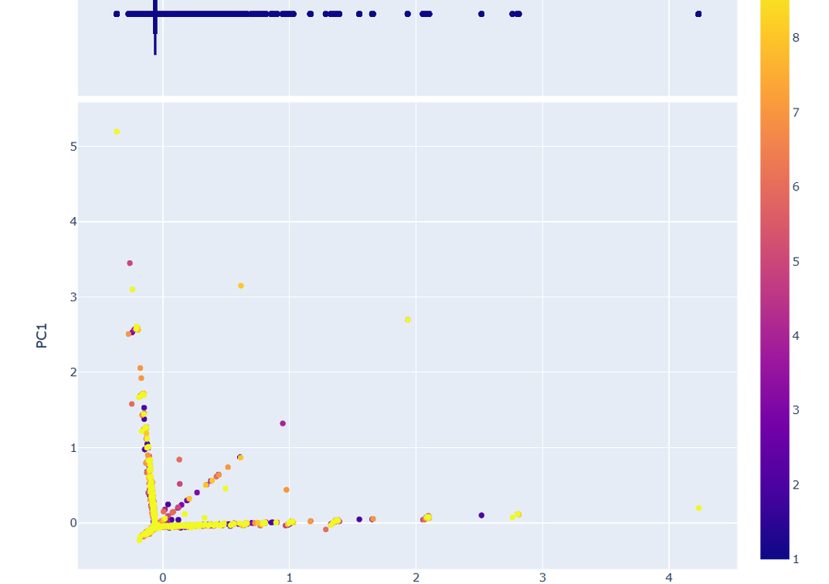

[figure not shown]

Most points are near 0, and there is a long tail to the right. The yellow values seem to be further out, and the blue and purple values seem to be closer to the left, which shows that this component comes out more in the later seasons.

## PCA Visualization 2 (4)

Include a scatterplot of documents in the space created by the second two components.

Color the points based on a metadata feature associated with the documents.

Also include a scatterplot of the loadings for the same two components. (This does not need a feature mapped onto color.)

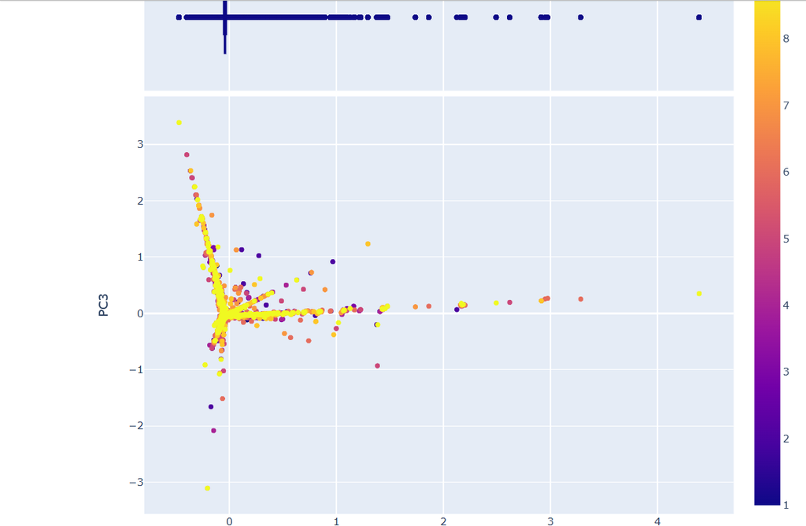

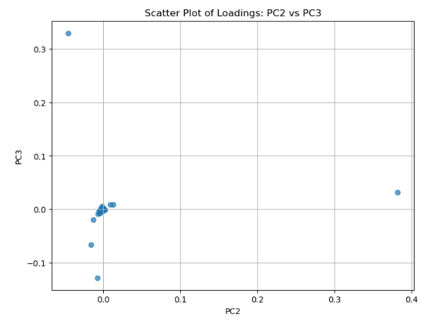

Briefly describe the nature of the polarity you see in the second component:

Again it's heavily concentrated around 0, with lots of positive skew, and PC2 seems to spread out as there's more yellow, which indicates that this component comes out more in the later seasons.

## LDA TOPIC (4)

- UVA Box URL: https://virginia.box.com/s/zf9hx4oeasgu0fh9glbl805duuy9tdcl
- UVA Box URL of count matrix used to create: https://virginia.box.com/s/wdvdgvog8fqp50bnzvhgph2tlpass6ps
- GitHub URL for notebook used to create: https://github.com/AndrewCornfeld/DS5001FinalProject/blob/master/LibCorpusVocabImport.ipynb
- Delimitter: ','
- Libary used to compute: CountVectorizer from sklearn.feature_extraction.text and LDA from sklearn.decomposition
- A description of any filtering, e.g. POS (Nouns and Verbs only): none
- Number of components: 40
- Any other parameters used: none
- Top 5 words and best-guess labels for topic five topics by mean document weight:
  - T00: accent, character, game, murder, punch (fighting, playing)
  - T01: time, phone, idea, yeah, office (official, organization in a sales sense)
  - T02: yeah, people, time, party, right (social events)
  - T03: phone, yeah, thing, office, day (organizing but in a planning sense)
  - T04: ok, movie, yeah, years, office (discussing their careers in a longevity sense)

## LDA THETA (4)

- UVA Box URL: https://virginia.box.com/s/243kfduwkiqdlm8lpfedcythq4r1mydp
- GitHub URL for notebook used to create: https://github.com/AndrewCornfeld/DS5001FinalProject/blob/master/LibCorpusVocabImport.ipynb
- Delimitter: ','

## LDA PHI (4)

- UVA Box URL: https://virginia.box.com/s/243kfduwkiqdlm8lpfedcythq4r1mydp
- GitHub URL for notebook used to create: https://github.com/AndrewCornfeld/DS5001FinalProject/blob/master/LibCorpusVocabImport.ipynb
- Delimitter: ','

## LDA + PCA Visualization (4)

Apply PCA to the PHI table and plot the topics in the space opened by the first two components.

Size the points based on the mean document weight of each topic (using the THETA table).

Color the points basd on a metadata feature from the LIB table.

Provide a brief interpretation of what you see.

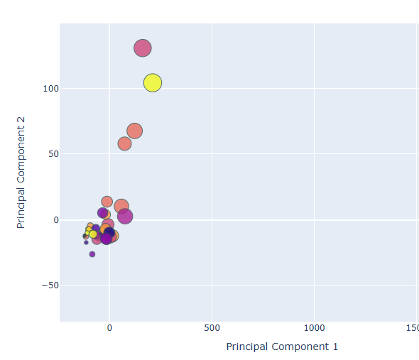

We can see that topics 6 and 11 are very high on the PC1 scale, which makes sense because PC1 is about organizational and sales and both of those have words like office, time, people, paper, which have to do a lot with the sales they do. One that is very low is 36, which has party, gift room, committee, all things that are kind of the opposite of sales.

## Sentiment VOCAB_SENT (4)

Sentiment values associated with a subset of the VOCAB from a curated sentiment lexicon.

- UVA Box URL: https://virginia.box.com/s/i2ousc2ivku44qkchrmhejesecpwh5iv
- UVA Box URL for source lexicon: https://virginia.box.com/s/g6qiuze3kiqt38zh2sh42in43hsqxjvi
- GitHub URL for notebook used to create: https://github.com/AndrewCornfeld/DS5001FinalProject/blob/master/LibCorpusVocabImport.ipynb
- Delimitter: ','

## Sentiment BOW_SENT (4)

Sentiment values from VOCAB_SENT mapped onto BOW.

- UVA Box URL: https://virginia.box.com/s/bar974pcjbsosi5y6zve3iw3x4n9zfxs
- GitHub URL for notebook used to create: https://github.com/AndrewCornfeld/DS5001FinalProject/blob/master/LibCorpusVocabImport.ipynb
- Delimitter: ','

## Sentiment DOC_SENT (4)

Computed sentiment per bag computed from BOW_SENT.

- UVA Box URL: https://virginia.box.com/s/8csoa4b8pbqy91abkw83zccmpkgfrvae
- GitHub URL for notebook used to create: https://github.com/AndrewCornfeld/DS5001FinalProject/blob/master/LibCorpusVocabImport.ipynb
- Delimitter: ','
- Document bag expressed in terms of OHCO levels: OHCO[:3]

## Sentiment Plot (4)

Plot sentiment over some metric space, such as time.

If you don't have a metric metadata features, plot sentiment over a feature of your choice.

You may use a bar chart or a line graph.

[figure not shown]

## VOCAB_W2V (4)

A table of word2vec features associated with terms in the VOCAB table.

- UVA Box URL: https://virginia.box.com/s/9lzg7bopnz7lt9m36i7ka8v5puto017d
- GitHub URL for notebook used to creat: https://github.com/AndrewCornfeld/DS5001FinalProject/blob/master/LibCorpusVocabImport.ipynb
- Delimitter: ','
- Document bag expressed in terms of OHCO levels: OHCO[:3]
- Number of features generated: 1109
- The library used to generate the embeddings: Word2Vec from gensim.models

## Word2vec tSNE Plot (4)

Plot word embedding featues in two-dimensions using t-SNE.

Describe a cluster in the plot that captures your attention.

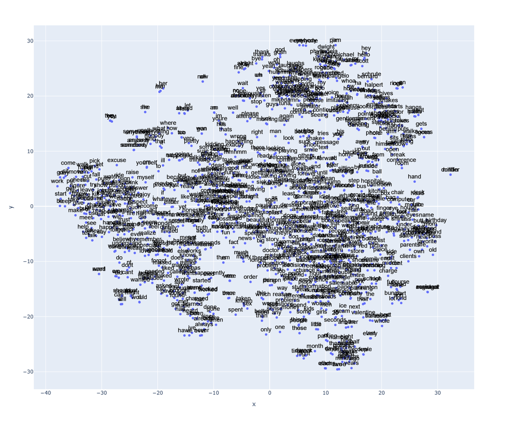

(INSERT DESCRIPTION HERE) I notice that all of the characters are in the top right corner, which I think is interesting. I also notice that within that cluster, characters that are similar in certain ways like Phyllis and Creed are in the same area, and characters like Jan and David are in their own similar area.

# Riffs

Provde at least three visualizations that combine the preceding model data in interesting ways.

These should provide insight into how features in the LIB table are related.

The nature of this relationship is left open to you -- it may be correlation, or mutual information, or something less well defined.

In doing so, consider the following visualization types:

- Hierarchical cluster diagrams
- Heatmaps
- Scatter plots
- KDE plots
- Dispersion plots
- t-SNE plots
- etc.

## Riff 1 (5)

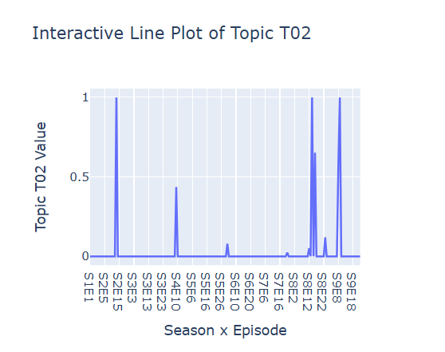

I decided to look more into topic 2, which was the one that had to do with partying and social events, and I looked into the peaks of that topic in this line plot. Season 2, episode 13 was the first peak, which is the episode where Jim has a crush on Pam and they go to Hooters, which makes sense. The tall peak far on the right is S9E9, where Dwight plans a christmas party (makes sense again), and the tall peak in the middle is about some of the people being in Florida while Andy has to cover for them.

## Riff 2 (5)

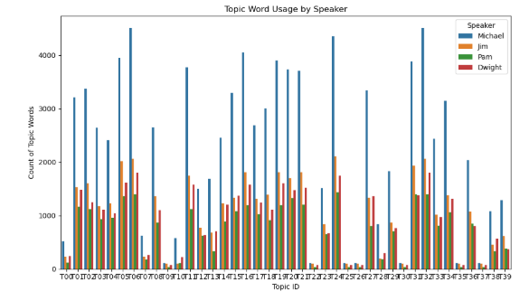

I decided to look more into each of the more prominent characters in the show, Michael, Jim, Pam, and Dwight, to see which characters were most prominently involved in each of the topics. It's clear with all of the blue that Michael is involved in nearly everything and is the most prominent person in all of the topics. This was calculated by using the top words and counting the number of times each top word was said by each person. Some things that stood out to me were that T1 (having a lot to do with phones and calling clients), Dwight and Jim were very high on these whereas Pam wasn't, which makes sense as she is a receptionist as opposed to a salesperson. You can also see that T0 is higher from Dwight and Jim (has to do with playfulness and fighting), as the two frequently "fight" each other in the show.

## Riff 3 (5)

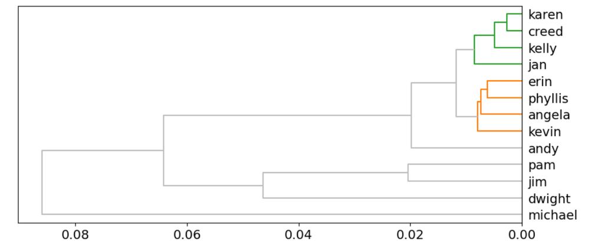

(INSERT INTERPRETATION HERE) I decided to see which characters are most similar to each other, and unsurprisingly Jim and Pam are very similar to each other, I think it's notable that Michael is the most dissimilar to everyone on the plot. I find it odd that Karen and Creed are the most similar, when I don't think they really interact at all in the show. It could possibly be that both of them, as well as Kelly and Jan aren't really large parts of the show. All of them have episodes where they're relevant but I wouldn't call any of them main characters. It is notable to me that Andy isn't closer to Jim or Dwight, especially since all of them are the big salesmen you think of in the show.

# Interpretation (4)

Describe something interesting about your corpus that you discovered during the process of completing this assignment.

At a minumum, use 250 words, but you may use more. You may also add images if you'd like.

(INSERT INTERPRETATION HERE) I think it was interesting to learn that some of the characters that weren't similar at all from watching the show turn out to be very similar when you analyze it. Noting that Kelly and Karen and Creed were all similar was strange to me. I can see how Kelly and Karen are similar as they both had very strange relationships with Jim, where Karen and Jim dated but Kelly often was romantically involved with Ryan. Phyllis, Kevin and Angela in the same area makes a lot of sense as they all seem to be a bit older and they all are in the same area of the office generally. In some ways though they all have very different personalities, with Kevin being very silly and Angela being very serious, which makes the graph look a little bit strange. It's interesting to see how you can use the topics to find an episode you want to watch. For example, I was looking at T10 and there are lots of words like warehouse, pizza, union, men, and the highest episode is Season 2 Episode 15, where Michael has his seminar in response to the Women in the Workplace seminar and hosts it with the men in the warehouse.

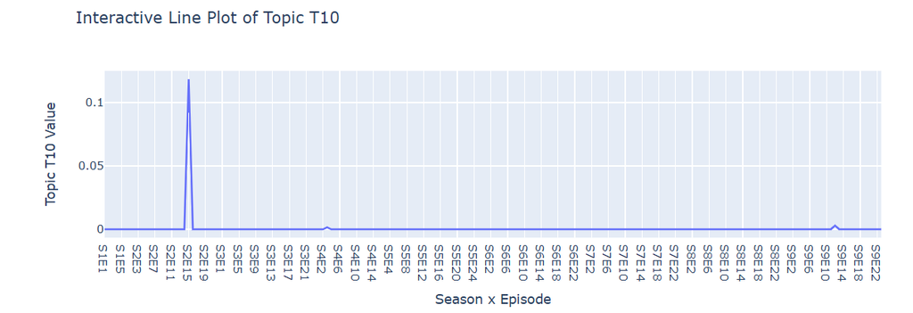

I also looked into T7, where the top terms were spot, scranton, montage, clip, and the top episode is Season 6, Episode 13, which is the Santa episode. I'm not sure if this is accurate, as I can't remember them showing any clips or montages in this episode, but there could be more I didn't consider. Overall, I thought this was a really interesting assignment and a way to further understand the script and how much nuance there is in the show.